# IRT model without subject covariates

Christoph Wunder

2022-08-05

In this file, we estimate and compare various IRT models **without** covariates. The results can be used to analyze easiness and item discrimination.

# 1 Data

The data are prepared starting in line 155 of the dofile `200-nfc-v3.do`.

```r
d <- read_dta("../data/master.dta")
d <- rename(d, id = idn)
d$id <- as.integer(d$id)
d$item <- as.factor(d$item)
d$lfa <- as.factor(d$lfa)
d$y <- factor( d$y, levels = c("0", "1", "2", "3"), ordered = TRUE )
```

Select subsample of data set:

```r
# set.seed(647382)
# n <- round(length(unique(d$id))*0.05, 0)
# samplecluster <- cluster(d, clustername=c("id"), size=n, method="srswor")
# dsample <- getdata(d, samplecluster)
# d <- dsample
```

# 2 Descriptive statistics

```r
nrow(d)
```

```
[1] 80343
```

```r
nrow(d)/9
```

```
[1] 8927
```

```r
summary(d)
```

```
       id             item       y             energy          industrial
 Min.   :    2   1      : 8927   0:30763   Min.   : 0.0000   Min.   : 0.000
 1st Qu.: 3922   2      : 8927   1:16995   1st Qu.: 0.0000   1st Qu.: 0.000
 Median : 7559   3      : 8927   2:16265   Median : 0.0000   Median : 0.000
 Mean   : 7788   4      : 8927   3:16320   Mean   : 0.8394   Mean   : 0.501
 3rd Qu.:11660   5      : 8927             3rd Qu.: 0.0000   3rd Qu.: 0.000
 Max.   :15789   6      : 8927             Max.   :92.4881   Max.   :97.207
                 (Other):26781
 lfa
 0:50112
 1:30231
```

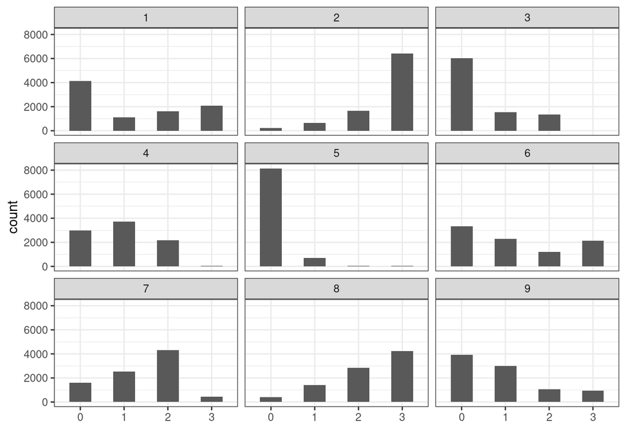

```r
ggplot( d, aes(x=y) ) +
  stat_count(width = 0.5) +
  xlab("") +
  facet_wrap(~item)
```

# 3 Fitting the ordinal one-parameter IRT model

We apply a graded response model to summarize the sustainability indicators that are measured on an ordinal four-point scale.

## 3.1 Shifted thresholds

We fit the ordered one-parameter IRT model with partially pooled person and item parameters. We model an overall threshold vector that is shared across items plus an item-specific constant, implying the (restrictive) assumption that the thresholds for two items are simply shifted to the left or right relative to each other but otherwise share the same shape.

```r
tic("fit1")
prior <-
  prior("normal(0, 3)", class = "sd", group = "id") +
  prior("normal(0, 3)", class = "sd", group = "item")

formula <- brmsformula( y ~ 1 +  (1|item) + (1|id) )

fit1 <- brm(
  formula = formula,
  data = d,
  family = cumulative(link = "logit"),
  prior = prior,
  cores = 8,
  iter = 1000,
  warmup = 500,
  refresh = 0,
  file = "../results/101-1pl.rds"
)
toc()
```

```
fit1: 2.782 sec elapsed
```

```r
prior_summary(fit1)
```

```
                prior     class      coef group resp dpar nlpar bound
 student_t(3, 0, 2.5) Intercept
 student_t(3, 0, 2.5) Intercept         1
 student_t(3, 0, 2.5) Intercept         2
 student_t(3, 0, 2.5) Intercept         3
 student_t(3, 0, 2.5)        sd
         normal(0, 3)        sd              id
         normal(0, 3)        sd Intercept    id
         normal(0, 3)        sd            item
         normal(0, 3)        sd Intercept  item
       source
      default
 (vectorized)
 (vectorized)
 (vectorized)
      default
         user
 (vectorized)
         user
 (vectorized)
```

```r
summary(fit1)
```

```
 Family: cumulative
  Links: mu = logit; disc = identity
Formula: y ~ 1 + (1 | item) + (1 | id)
   Data: d (Number of observations: 80343)
  Draws: 4 chains, each with iter = 1000; warmup = 500; thin = 1;
         total post-warmup draws = 2000

Group-Level Effects:
~id (Number of levels: 8927)
              Estimate Est.Error l-95% CI u-95% CI Rhat Bulk_ESS Tail_ESS
sd(Intercept)     0.34      0.01     0.32     0.37 1.01      758     1174

~item (Number of levels: 9)
              Estimate Est.Error l-95% CI u-95% CI Rhat Bulk_ESS Tail_ESS
sd(Intercept)     1.99      0.56     1.21     3.33 1.00      852      976

Population-Level Effects:
             Estimate Est.Error l-95% CI u-95% CI Rhat Bulk_ESS Tail_ESS
Intercept[1]    -0.85      0.63    -2.12     0.45 1.01      548      910
Intercept[2]     0.42      0.63    -0.85     1.71 1.01      547      910
Intercept[3]     1.89      0.63     0.62     3.18 1.01      547      934

Family Specific Parameters:
     Estimate Est.Error l-95% CI u-95% CI Rhat Bulk_ESS Tail_ESS
disc     1.00      0.00     1.00     1.00   NA       NA       NA

Draws were sampled using sampling(NUTS). For each parameter, Bulk_ESS
and Tail_ESS are effective sample size measures, and Rhat is the potential
scale reduction factor on split chains (at convergence, Rhat = 1).
```

Extract diagnostic quantities, extract the number of divergence transitions:

```r
np <- nuts_params(fit1)
sum(subset(np, Parameter == "divergent__")$Value)
```

```
[1] 0
```

## 3.2 Separate threshold vectors

Next, we estimate a model where each item receives its own threshold vector. In doing so, we relax the assumption of shifted but equally shaped threshold vectors across items. Instead, we allow threshold locations and shapes to vary freely across items.

```r
tic("fit2")
prior_thres_1pl <-
  prior("normal(0, 3)", class = "Intercept") +
  prior("normal(0, 3)", class = "sd", group = "id")

formula <- brmsformula( y | thres(gr = item) ~ 1 + (1|id) )

fit2 <- brm(
  formula = formula,
  data = d,
  family = cumulative(link = "logit"),
  prior = prior_thres_1pl,
  cores = 8,
  iter = 1000,
  warmup = 500,
  refresh = 0,
  file = "../results/102-1pl-thres.rds"
)
toc()
```

```
fit2: 1.712 sec elapsed
```

```r
summary(fit2)
```

```
 Family: cumulative
  Links: mu = logit; disc = identity
Formula: y | thres(gr = item) ~ 1 + (1 | id)
   Data: d (Number of observations: 80343)
  Draws: 4 chains, each with iter = 1000; warmup = 500; thin = 1;
         total post-warmup draws = 2000

Group-Level Effects:
~id (Number of levels: 8927)
              Estimate Est.Error l-95% CI u-95% CI Rhat Bulk_ESS Tail_ESS
sd(Intercept)     0.28      0.02     0.25     0.31 1.01      449      794

Population-Level Effects:
               Estimate Est.Error l-95% CI u-95% CI Rhat Bulk_ESS Tail_ESS
Intercept[1,1]    -0.16      0.02    -0.20    -0.11 1.01     2755     1421
Intercept[1,2]     0.35      0.02     0.31     0.40 1.00     3478     1443
Intercept[1,3]     1.23      0.02     1.18     1.28 1.00     2923     1266
Intercept[2,1]    -3.77      0.07    -3.92    -3.64 1.00     1712     1565
Intercept[2,2]    -2.26      0.04    -2.33    -2.19 1.00     2513     1706
Intercept[2,3]    -0.95      0.02    -0.99    -0.90 1.00     2012     1386
Intercept[3,1]     0.75      0.02     0.71     0.79 1.00     3176     1449
Intercept[3,2]     1.76      0.03     1.70     1.82 1.01     3432     1264
Intercept[3,3]     7.91      0.51     7.01     9.00 1.00     3613     1394
Intercept[4,1]    -0.69      0.02    -0.74    -0.65 1.00     2331     1449
Intercept[4,2]     1.13      0.03     1.08     1.18 1.00     3062     1377
Intercept[4,3]     5.86      0.20     5.49     6.27 1.00     3915     1386
Intercept[5,1]     2.36      0.04     2.29     2.43 1.00     2975     1377
Intercept[5,2]     4.59      0.10     4.39     4.80 1.00     3113     1332
Intercept[5,3]     5.58      0.17     5.26     5.94 1.00     3647     1299
Intercept[6,1]    -0.53      0.02    -0.58    -0.49 1.00     2265     1293
Intercept[6,2]     0.52      0.02     0.48     0.56 1.00     3037     1309
Intercept[6,3]     1.17      0.03     1.12     1.22 1.00     3044     1470
Intercept[7,1]    -1.53      0.03    -1.58    -1.47 1.00     2281     1465
Intercept[7,2]    -0.13      0.02    -0.17    -0.09 1.01     2095     1356
Intercept[7,3]     2.94      0.05     2.85     3.03 1.00     2816     1760
Intercept[8,1]    -3.10      0.05    -3.20    -3.00 1.00     1688     1292
Intercept[8,2]    -1.38      0.03    -1.44    -1.33 1.00     2287     1515
Intercept[8,3]     0.10      0.02     0.06     0.15 1.00     1904     1380
Intercept[9,1]    -0.24      0.02    -0.29    -0.20 1.00     2603     1695
Intercept[9,2]     1.27      0.03     1.22     1.32 1.00     3771     1497
Intercept[9,3]     2.18      0.04     2.11     2.26 1.00     3642     1391

Family Specific Parameters:
     Estimate Est.Error l-95% CI u-95% CI Rhat Bulk_ESS Tail_ESS
disc     1.00      0.00     1.00     1.00   NA       NA       NA

Draws were sampled using sampling(NUTS). For each parameter, Bulk_ESS
and Tail_ESS are effective sample size measures, and Rhat is the potential
scale reduction factor on split chains (at convergence, Rhat = 1).
```

Extract diagnostic quantities:

```r
np <- nuts_params(fit2)
sum(subset(np, Parameter == "divergent__")$Value)
```

```
[1] 0
```

We compare the models using approximate LOO-CV:

```r
loo_compare(loo(fit1), loo(fit2))
```

```
     elpd_diff se_diff
fit2     0.0       0.0
fit1 -4670.4      85.4
```

We reject the assumption of only shifted thresholds.

# 4 Fitting the ordered two-parameter IRT model

## 4.1 Shifted thresholds

```r
tic("fit3")
prior <-
  # discrimination
  prior("normal(0, 1)", class = "Intercept", dpar = "disc") +             # alpha
  prior("normal(0, 1)", class = "sd", group = "item", dpar = "disc") +    # sigma_alpha
  # unit-specific effects
  prior("constant(1)", class = "sd", group = "id") +
  # item-specific effects
  prior("normal(0, 1)", class = "sd", coef = "Intercept", group = "item")

formula <- brmsformula(
  y ~ 1 + (1|i|item) + (1|id),
  disc ~ 1 + (1|i|item)
)

fit3 <- brm(
  formula = formula,
  data = d,
  family = cumulative(link = "logit"),
  prior = prior,
  cores = 8,
  iter = 1000,
  warmup = 500,
  refresh = 0,
  file = "../results/103-2pl.rds"
)
toc()
```

```
fit3: 8774.361 sec elapsed
```

```r
prior_summary(fit3)
```

```
                prior     class      coef group resp dpar nlpar bound
 student_t(3, 0, 2.5) Intercept
 student_t(3, 0, 2.5) Intercept         1
 student_t(3, 0, 2.5) Intercept         2
 student_t(3, 0, 2.5) Intercept         3
         normal(0, 1) Intercept                      disc
 lkj_corr_cholesky(1)         L
 lkj_corr_cholesky(1)         L            item
 student_t(3, 0, 2.5)        sd
 student_t(3, 0, 2.5)        sd                      disc
          constant(1)        sd              id
          constant(1)        sd Intercept    id
 student_t(3, 0, 2.5)        sd            item
         normal(0, 1)        sd Intercept  item
         normal(0, 1)        sd            item      disc
         normal(0, 1)        sd Intercept  item      disc
       source
      default
 (vectorized)
 (vectorized)
 (vectorized)
         user
      default
 (vectorized)
      default
      default
         user
 (vectorized)
 (vectorized)
         user
         user
 (vectorized)
```

```r
summary(fit3)
```

```
 Family: cumulative
  Links: mu = logit; disc = log
Formula: y ~ 1 + (1 | i | item) + (1 | id)
         disc ~ 1 + (1 | i | item)
   Data: d (Number of observations: 80343)
  Draws: 4 chains, each with iter = 1000; warmup = 500; thin = 1;
         total post-warmup draws = 2000

Group-Level Effects:
~id (Number of levels: 8927)
              Estimate Est.Error l-95% CI u-95% CI Rhat Bulk_ESS Tail_ESS
sd(Intercept)     1.00      0.00     1.00     1.00   NA       NA       NA

~item (Number of levels: 9)
                              Estimate Est.Error l-95% CI u-95% CI Rhat
sd(Intercept)                     4.35      0.48     3.51     5.39 1.00
sd(disc_Intercept)                0.51      0.14     0.30     0.87 1.00
cor(Intercept,disc_Intercept)    -0.11      0.18    -0.47     0.25 1.00
                              Bulk_ESS Tail_ESS
sd(Intercept)                     1051     1350
sd(disc_Intercept)                 863     1069
cor(Intercept,disc_Intercept)      892     1129

Population-Level Effects:
               Estimate Est.Error l-95% CI u-95% CI Rhat Bulk_ESS Tail_ESS
Intercept[1]      -4.30      1.41    -7.16    -1.52 1.02      274      436
Intercept[2]       1.44      1.41    -1.36     4.22 1.01      316      466
Intercept[3]       9.07      1.54     6.18    12.11 1.01      353      682
disc_Intercept    -1.51      0.18    -1.84    -1.12 1.01      596      767

Draws were sampled using sampling(NUTS). For each parameter, Bulk_ESS
and Tail_ESS are effective sample size measures, and Rhat is the potential
scale reduction factor on split chains (at convergence, Rhat = 1).
```

Extract diagnostic quantities:

```r
np <- nuts_params(fit3)
sum(subset(np, Parameter == "divergent__")$Value)
```

```
[1] 4
```

## 4.2 Item-specific thresholds

We add a discrimination parameter and maintain item-specific thresholds.

```r
tic("fit4")
prior_thres_2pl <-
  prior("normal(0, 3)", class = "Intercept") +
  prior("normal(0, 3)", class = "sd", group = "id") +
  prior("normal(0, 3)", class = "sd", group = "item", dpar = "disc")

formula <- brmsformula( y | thres(gr = item) ~ 1 + (1|id),
                        disc ~ (1|item))

fit4 <- brm(
  formula = formula,
  data = d,
  family = cumulative(link = "logit"),
  prior = prior_thres_2pl,
  cores = 8,
  iter = 1000,
  warmup = 500,
  refresh = 0,
  file = "../results/104-2pl-thres.rds"
)
toc()
```

```
fit4: 1.493 sec elapsed
```

```r
prior_summary(fit4)
```

```
                prior     class      coef group resp dpar nlpar bound
         normal(0, 3) Intercept
         normal(0, 1) Intercept                      disc
         normal(0, 3) Intercept               1
         normal(0, 3) Intercept         1     1
         normal(0, 3) Intercept         2     1
         normal(0, 3) Intercept         3     1
         normal(0, 3) Intercept               2
         normal(0, 3) Intercept         1     2
         normal(0, 3) Intercept         2     2
         normal(0, 3) Intercept         3     2
         normal(0, 3) Intercept               3
         normal(0, 3) Intercept         1     3
         normal(0, 3) Intercept         2     3
         normal(0, 3) Intercept         3     3
         normal(0, 3) Intercept               4
         normal(0, 3) Intercept         1     4
         normal(0, 3) Intercept         2     4
         normal(0, 3) Intercept         3     4
         normal(0, 3) Intercept               5
         normal(0, 3) Intercept         1     5
         normal(0, 3) Intercept         2     5
         normal(0, 3) Intercept         3     5
         normal(0, 3) Intercept               6
         normal(0, 3) Intercept         1     6
         normal(0, 3) Intercept         2     6
         normal(0, 3) Intercept         3     6
         normal(0, 3) Intercept               7
         normal(0, 3) Intercept         1     7
         normal(0, 3) Intercept         2     7
         normal(0, 3) Intercept         3     7
         normal(0, 3) Intercept               8
         normal(0, 3) Intercept         1     8
         normal(0, 3) Intercept         2     8
         normal(0, 3) Intercept         3     8
         normal(0, 3) Intercept               9
         normal(0, 3) Intercept         1     9
         normal(0, 3) Intercept         2     9
         normal(0, 3) Intercept         3     9
 student_t(3, 0, 2.5)        sd
```

[output cut: 35 more lines]

```
 (vectorized)
 (vectorized)
 (vectorized)
 (vectorized)
 (vectorized)
 (vectorized)
 (vectorized)
 (vectorized)
 (vectorized)
      default
      default
         user
 (vectorized)
         user
 (vectorized)
```

```r
summary(fit4)
```

```
 Family: cumulative
  Links: mu = logit; disc = log
Formula: y | thres(gr = item) ~ 1 + (1 | id)
         disc ~ (1 | item)
   Data: d (Number of observations: 80343)
  Draws: 4 chains, each with iter = 1000; warmup = 500; thin = 1;
         total post-warmup draws = 2000

Group-Level Effects:
~id (Number of levels: 8927)
              Estimate Est.Error l-95% CI u-95% CI Rhat Bulk_ESS Tail_ESS
sd(Intercept)     0.03      0.01     0.02     0.04 1.04       87      243

~item (Number of levels: 9)
                   Estimate Est.Error l-95% CI u-95% CI Rhat Bulk_ESS Tail_ESS
sd(disc_Intercept)     3.57      0.87     2.25     5.47 1.04      179      513

Population-Level Effects:
               Estimate Est.Error l-95% CI u-95% CI Rhat Bulk_ESS Tail_ESS
Intercept[1,1]    -0.00      0.00    -0.00    -0.00 1.05       61      133
Intercept[1,2]     0.01      0.00     0.00     0.01 1.06       72      167
Intercept[1,3]     0.02      0.01     0.01     0.03 1.04       87      256
Intercept[2,1]    -5.38      1.48    -8.56    -2.87 1.01      318      520
Intercept[2,2]    -3.20      0.88    -5.06    -1.71 1.01      322      502
Intercept[2,3]    -1.34      0.37    -2.14    -0.71 1.01      325      552
Intercept[3,1]     0.03      0.01     0.02     0.05 1.03       91      254
Intercept[3,2]     0.08      0.02     0.04     0.12 1.03       90      241
Intercept[3,3]     0.34      0.09     0.19     0.54 1.03      101      241
Intercept[4,1]    -0.98      0.22    -1.43    -0.58 1.01      294      601
Intercept[4,2]     1.60      0.35     0.94     2.33 1.01      306      627
Intercept[4,3]     8.30      1.79     5.03    12.10 1.01      296      680
Intercept[5,1]     1.06      0.46     0.40     2.16 1.04      136      461
Intercept[5,2]     2.07      0.90     0.78     4.28 1.04      134      403
Intercept[5,3]     2.52      1.10     0.95     5.20 1.04      129      426
Intercept[6,1]    -2.56      0.74    -4.13    -1.21 1.03      111      226
Intercept[6,2]     2.48      0.69     1.20     3.89 1.02      124      241
Intercept[6,3]     5.57      1.56     2.68     8.73 1.03      119      208
Intercept[7,1]    -0.12      0.03    -0.19    -0.07 1.03       90      251
Intercept[7,2]    -0.01      0.00    -0.01    -0.00 1.02      131      459
Intercept[7,3]     0.23      0.06     0.13     0.37 1.03       90      244
Intercept[8,1]    -0.05      0.01    -0.08    -0.03 1.03       88      262
Intercept[8,2]    -0.03      0.01    -0.04    -0.01 1.03       87      251
Intercept[8,3]     0.00      0.00     0.00     0.00 1.13       24       39
Intercept[9,1]    -0.80      0.19    -1.19    -0.46 1.03      211      528
Intercept[9,2]     4.18      0.91     2.54     6.07 1.03      222      716
Intercept[9,3]     7.20      1.57     4.41    10.50 1.03      220      661
disc_Intercept     0.83      0.75    -0.66     2.29 1.02      160      413

Draws were sampled using sampling(NUTS). For each parameter, Bulk_ESS
and Tail_ESS are effective sample size measures, and Rhat is the potential
scale reduction factor on split chains (at convergence, Rhat = 1).
```

Extract diagnostic quantities:

```r
np <- nuts_params(fit4)
sum(subset(np, Parameter == "divergent__")$Value)
```

```
[1] 139
```

## 4.3 Model comparision

```r
loo_compare(loo(fit1), loo(fit2), loo(fit3), loo(fit4))
```

```
     elpd_diff se_diff
fit4      0.0       0.0
fit2 -13600.6     123.1
fit3 -15123.3     133.9
fit1 -18271.0     147.2
```

# 5 Interpretation

## 5.1 Easiness and discrimination from two-parameter IRT model with shifted thresholds (model 3)

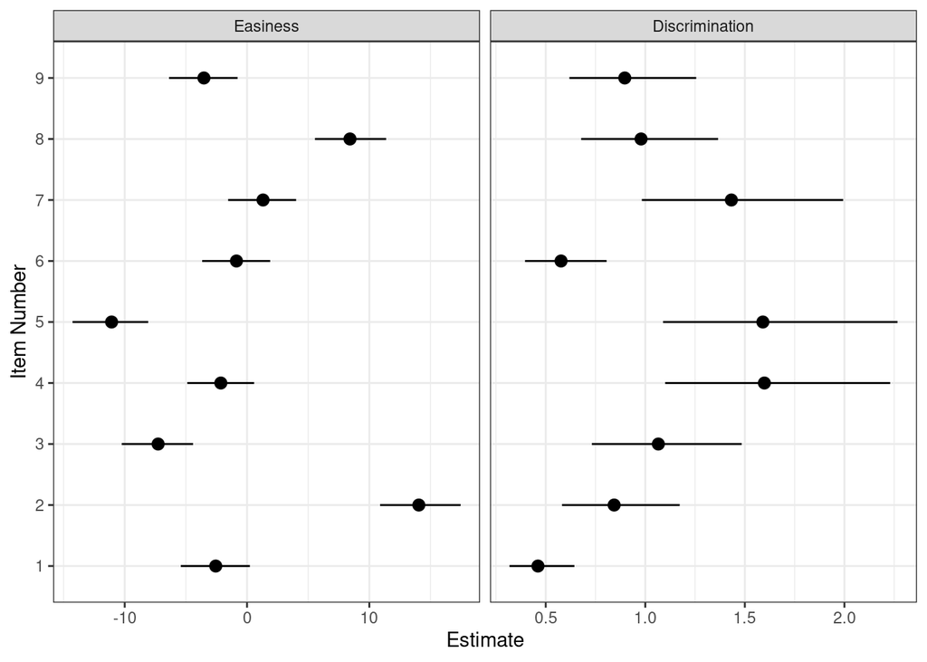

```r
# extract item and easiness parameters
ranef1 <- ranef(fit3)
# discriminations
alpha <- ranef1$item[, , "disc_Intercept"] %>%
  exp() %>%
    as_tibble() %>%
    rownames_to_column()
# item easinesses (deviations from thresholds)
beta <- ranef1$item[, , "Intercept"] %>%
    as_tibble() %>%
    rownames_to_column()
# put easinesses and discriminations together
bind_rows(beta, alpha, .id = "nlpar") %>%
    rename(item = "rowname") %>%
    mutate(item = as.numeric(item)) %>%
    mutate(nlpar = factor(nlpar, labels = c("Easiness", "Discrimination"))) %>%
    ggplot(aes(item, Estimate, ymin = Q2.5, ymax = Q97.5)) +
    facet_wrap("nlpar", scales = "free_x") +
    geom_pointrange() +
    coord_flip() +
    labs(x = "Item Number") +
  scale_x_discrete( limits=1:9 )
```

## 5.2 Discrimination from two-parameter IRT model with item-specific thresholds (model 4)

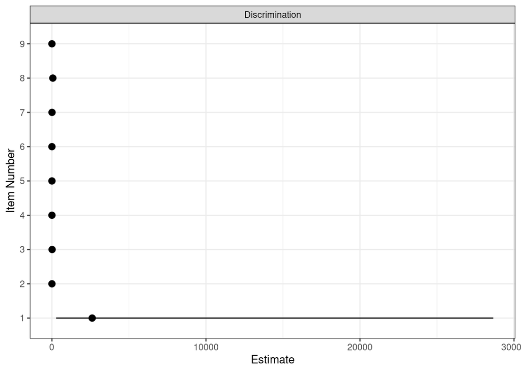

```r
# extract item and easiness parameters
ranef1 <- ranef(fit4)
# discriminations
alpha <- ranef1$item[, , "disc_Intercept"] %>%
  exp() %>%
    as_tibble() %>%
    rownames_to_column()
# # item easinesses (deviations from thresholds)
# beta <- ranef1$item[, , "Intercept"] %>%
#     as_tibble() %>%
#     rownames_to_column()
# put easinesses and discriminations together
bind_rows(alpha, .id = "nlpar") %>%
    rename(item = "rowname") %>%
    mutate(item = as.numeric(item)) %>%
    mutate(nlpar = factor(nlpar, labels = c("Discrimination"))) %>%
    ggplot(aes(item, Estimate, ymin = Q2.5, ymax = Q97.5)) +
    facet_wrap("nlpar", scales = "free_x") +
    geom_pointrange() +
    coord_flip() +
    labs(x = "Item Number") +
  scale_x_discrete( limits=1:9 )
```

```r
knitr::knit_exit()
```